# Time Series Analysis of Energy Production data

David

2024-09-20

```r
# Load packages
pacman::p_load(tidyverse, ggfortify, tseries, forecast)
```

```r
# Import data
Electric_Production <- read_csv("Electric_Production.csv")
```

The data has 397 observations of 2 variables. Date is coded as a character string and Value is a numeric variable (double) containing the monthly quantity of electricity produced.

```r
# View the first few observations
head(Electric_Production)
```

```
## # A tibble: 6 × 2
##   Date       Value
##   <chr>      <dbl>
## 1 01/01/1985  72.5
## 2 02/01/1985  70.7
## 3 03/01/1985  62.5
## 4 04/01/1985  57.5
## 5 05/01/1985  55.3
## 6 06/01/1985  58.1
```

The first observation was recorded on January 1st, 1985.

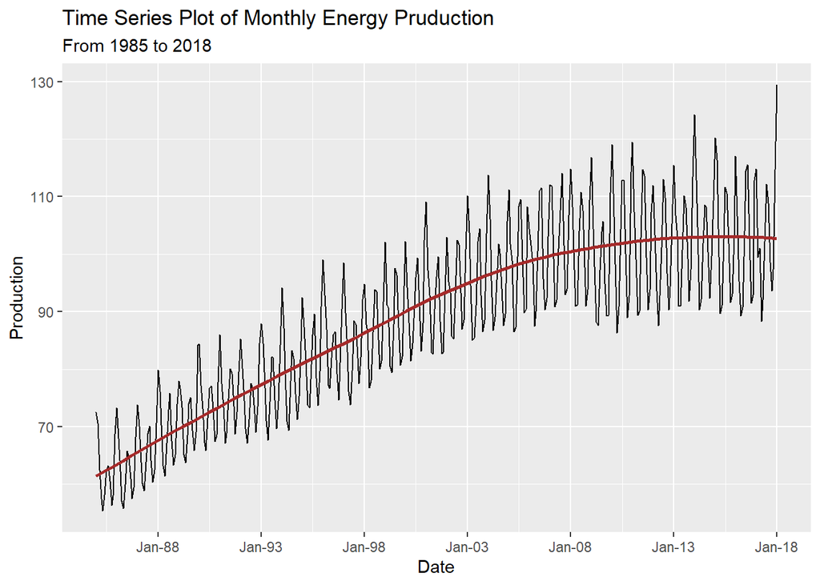

```r
# Plot the Time Series

# First convert the Date Column into a proper date format
Electric_Production[["Date"]] <- as.Date(Electric_Production[["Date"]],
                                         format = "%m/%d/%Y")
# Plot
# define grid and aesthetic mappings
ggplot(Electric_Production, aes(x = Date, y = Value)) +
  # add a line plot layer
  geom_line() +
  # add a smoothing layer to depict the trend, suppress the SE
  geom_smooth(color = "brown", se = F) +
  # use 5 years interval on the X-axis
  scale_x_date(date_breaks = "5 years", date_labels = "%b-%y") +
  # add a title and a subtitle
  labs(title = "Time Series Plot of Monthly Energy Pruduction",
       subtitle = "From 1985 to 2018", y = "Production")
```

```r
# Convert the data into a time series object (the data is a monthly series starting from January 1985)
Production <- ts(Electric_Production$Value, frequency = 12, start = c(1985,1))
```

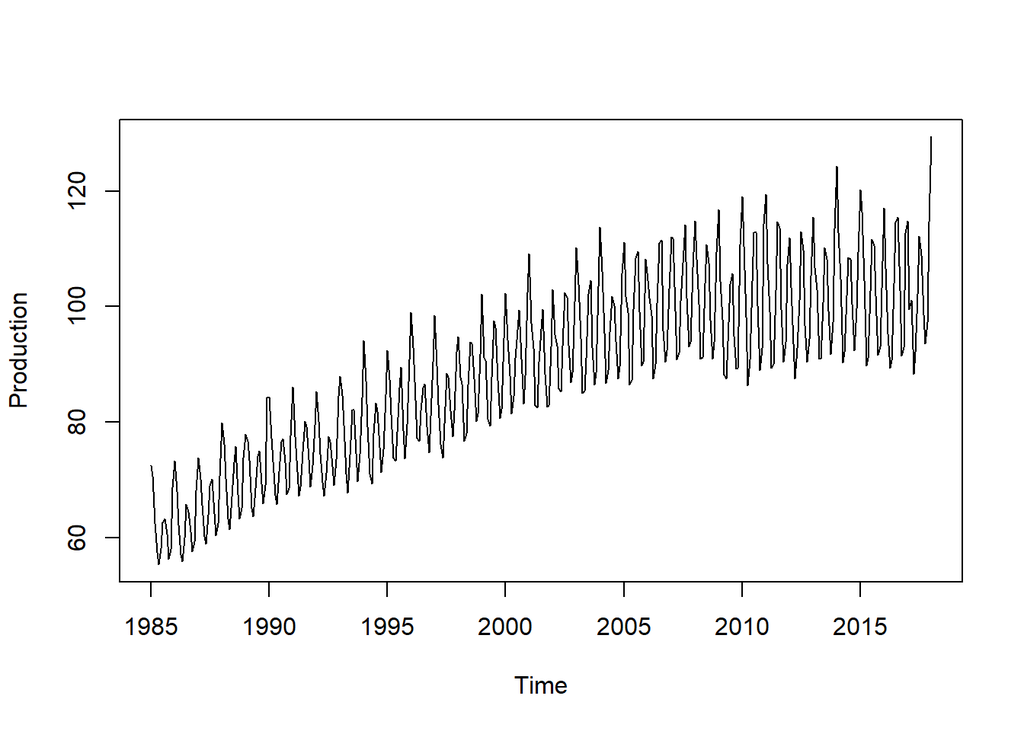

```r
# Plot the time series using ts.plot() function from stats package
ts.plot(Production)
```

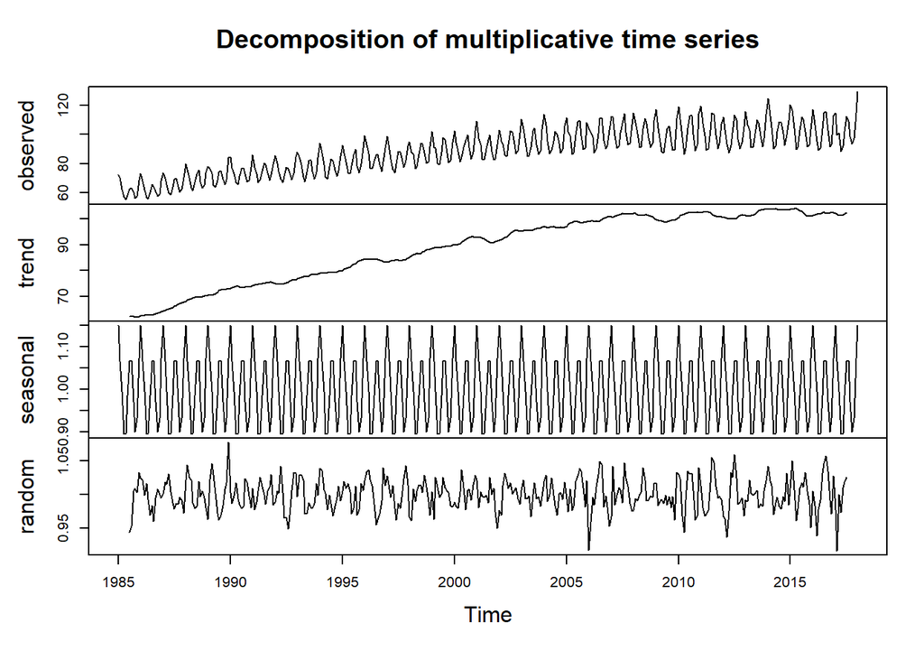

```r
# Decompose the series to separate it into its constituent elements
Production_decomposed <- decompose(Production, type = "multiplicative")

# plot the decomposed series
plot(Production_decomposed)
```

The upward trend is now clearly depicted in the decomposed time series. The seasonality and the random components are also clearly visible now.

```r
# Get the estimated values of seasonal component
Production_decomposed$seasonal
```

```
##            Jan       Feb       Mar       Apr       May       Jun       Jul
## 1985 1.1491719 1.0658752 0.9959854 0.8960271 0.8967243 0.9849000 1.0661453
## 1986 1.1491719 1.0658752 0.9959854 0.8960271 0.8967243 0.9849000 1.0661453
## 1987 1.1491719 1.0658752 0.9959854 0.8960271 0.8967243 0.9849000 1.0661453
## 1988 1.1491719 1.0658752 0.9959854 0.8960271 0.8967243 0.9849000 1.0661453
## 1989 1.1491719 1.0658752 0.9959854 0.8960271 0.8967243 0.9849000 1.0661453
## 1990 1.1491719 1.0658752 0.9959854 0.8960271 0.8967243 0.9849000 1.0661453
## 1991 1.1491719 1.0658752 0.9959854 0.8960271 0.8967243 0.9849000 1.0661453
## 1992 1.1491719 1.0658752 0.9959854 0.8960271 0.8967243 0.9849000 1.0661453
## 1993 1.1491719 1.0658752 0.9959854 0.8960271 0.8967243 0.9849000 1.0661453
## 1994 1.1491719 1.0658752 0.9959854 0.8960271 0.8967243 0.9849000 1.0661453
## 1995 1.1491719 1.0658752 0.9959854 0.8960271 0.8967243 0.9849000 1.0661453
## 1996 1.1491719 1.0658752 0.9959854 0.8960271 0.8967243 0.9849000 1.0661453
## 1997 1.1491719 1.0658752 0.9959854 0.8960271 0.8967243 0.9849000 1.0661453
## 1998 1.1491719 1.0658752 0.9959854 0.8960271 0.8967243 0.9849000 1.0661453
```

[output cut: 55 more lines]

The largest seasonal component is in January (about 1.1491) and the lowest is in April (about 0.8960), indicating that there is a peak in electricity production every January and a trough every April each year.

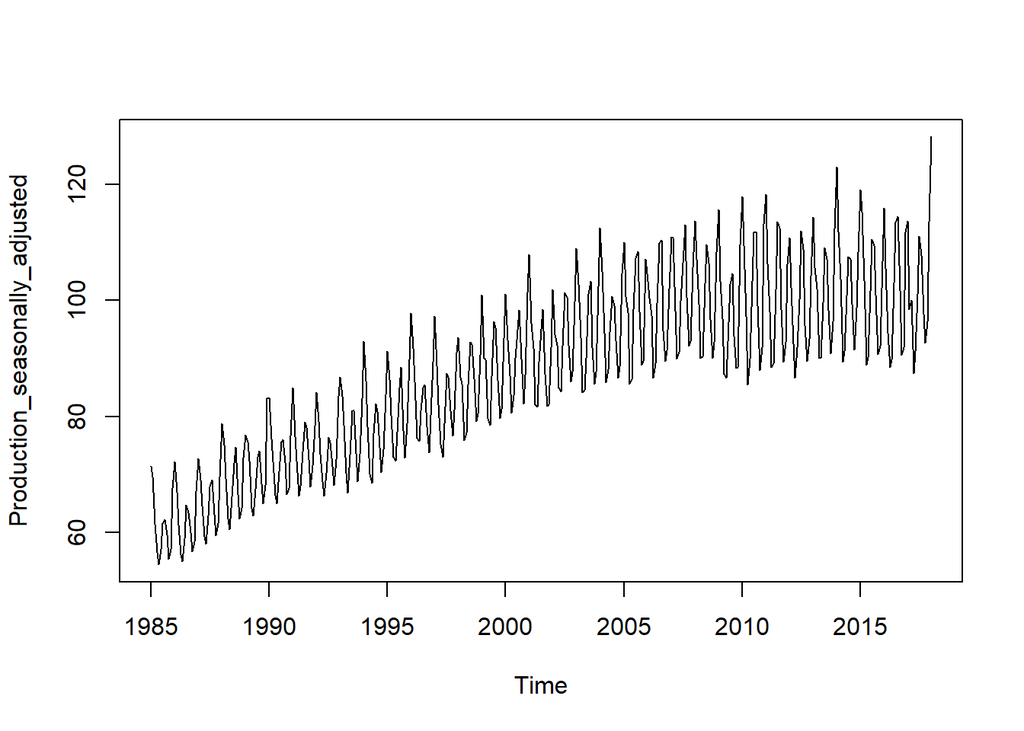

```r
# Seasonally adjusting the series (removing the seasonality component)
Production_seasonally_adjusted <- Production - Production_decomposed$seasonal
# Plot the seasonally adjusted series
plot(Production_seasonally_adjusted)
```

The production series seems to have increasing variance towards the end of the series, I’ll make the variance stationary by finding the log of the series.

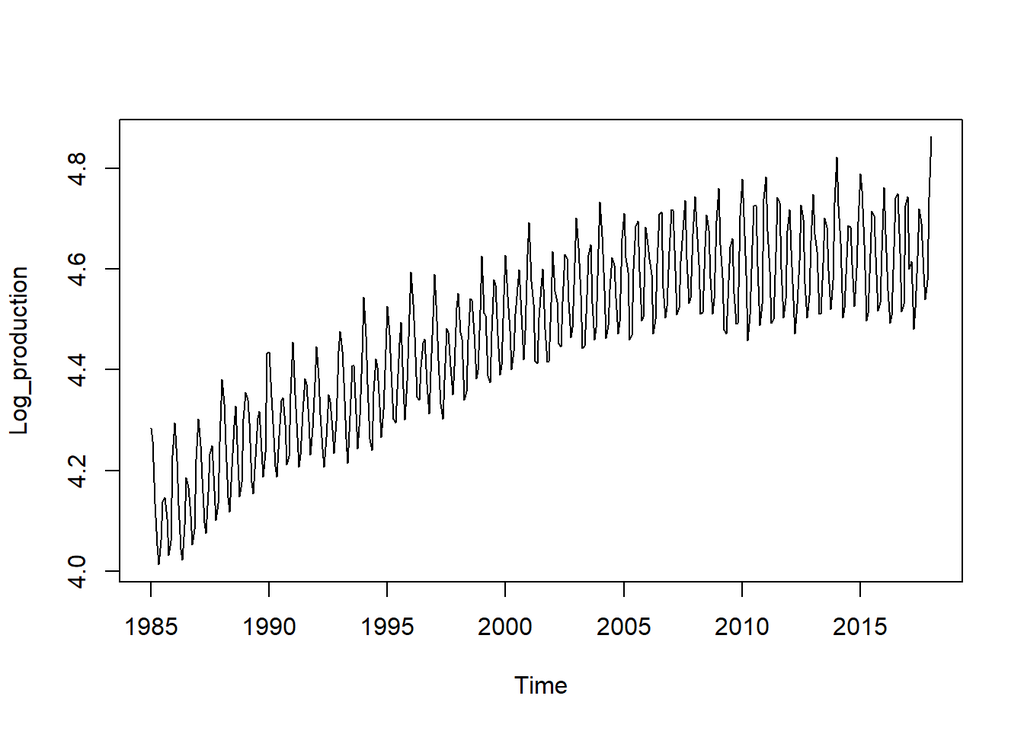

```r
# Log-transform the series
Log_production <- log(Production)

# Plot the log transformed series
ts.plot(Log_production)
```

The variance of the log transformed series is now stationary.

# FORECASTING

Before forecasting, I’ll first partition the data into training and test sets, use the training set for model training and test set for evaluating how the model will generalize on unseen data. I will use two models for forecasting i.e. Holt-Winters Exponential Smoothing and Seasonal ARIMA, since my log-transformed series has both the trend and seasonality components, and can be described using an additive model.

```r
# Data Partitioning (use 85 - 15% split)
training_data <- Electric_Production[1:337, ]
# Log-transform the training set
train <- log(ts(training_data$Value, frequency = 12, start = c(1985,1)))
test_data <- Electric_Production[338:397, ]
# Log-transform the test set
test <- log(ts(test_data$Value, frequency = 12, start = c(2013,2)))
```

```r
# Forecast using Holt-Winters Exponential Smoothing
Production_forecasts <- HoltWinters(train) # in-sample forecasts
# View model results
Production_forecasts
```

```
## Holt-Winters exponential smoothing with trend and additive seasonal component.
##
## Call:
## HoltWinters(x = train)
##
## Smoothing parameters:
##  alpha: 0.4301033
##  beta : 0
##  gamma: 0.4297328
##
## Coefficients:
##             [,1]
## a    4.605707285
## b    0.001147011
## s1   0.056835766
## s2  -0.024228312
## s3  -0.113358758
## s4  -0.084575097
## s5   0.022678208
## s6   0.108935360
## s7   0.094826055
## s8  -0.026441498
## s9  -0.107296022
## s10 -0.075279907
## s11  0.072681625
## s12  0.138968771
```

Both alpha and gamma are relatively low (0.4301 and 0.4297 respectively) indicating that the estimate of the level and the estimate of the seasonal component at the current time point are based upon both recent observations and some observations in the distant past, with more weight placed on the most recent observations. The value of beta is 0.00, indicating that the estimate of the slope b of the trend component is not updated over the time series, and instead is set equal to its initial value.

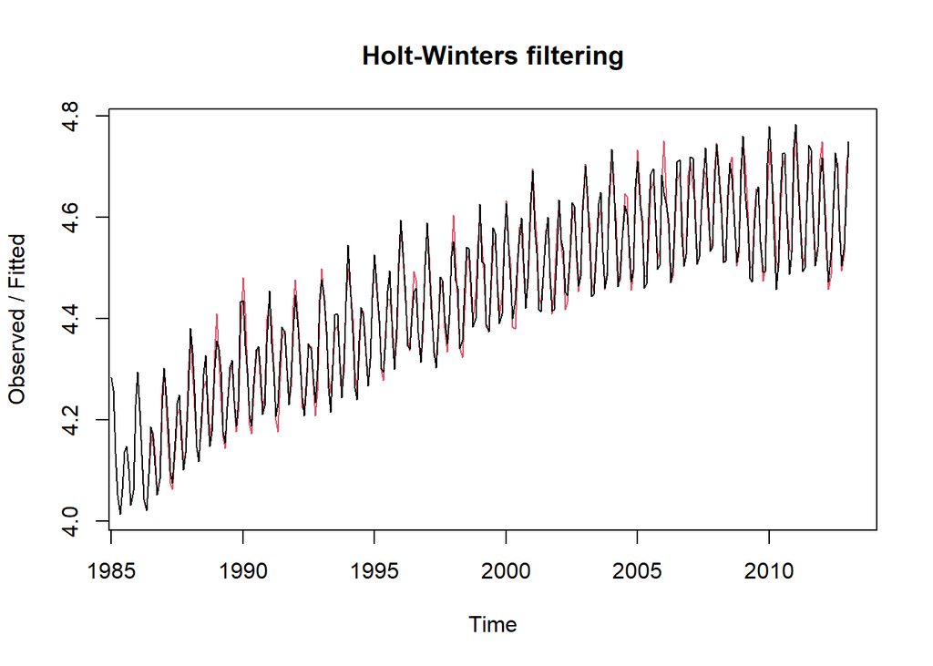

```r
# Plot the in-sample forecasts
plot(Production_forecasts)
```

The forecasts made by Holt-Winters Exponential Smoothing model looks good and closely follows the original series. However, the model seems to over predict some of the seasonal peaks.

```r
# Find the in-sample forecast error
Production_forecasts$SSE
```

```
## [1] 0.2096753
```

Error sum of squares (0.2097) is closer to zero indicating a good performance.

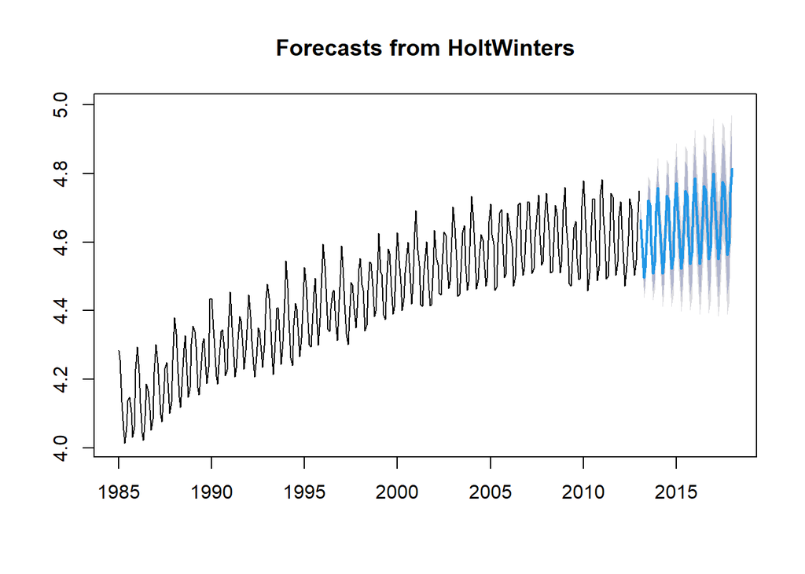

```r
# Forecast for the next five years i.e. sixty months ahead.
Production_forecasts2 <- forecast(Production_forecasts, h = 60)
# Plot the full forecast
plot(Production_forecasts2)
```

The forecast closely follows the original series. It is important to note that Exponential Smoothing models are good for short-term forecasts.

# Model Diagnostics

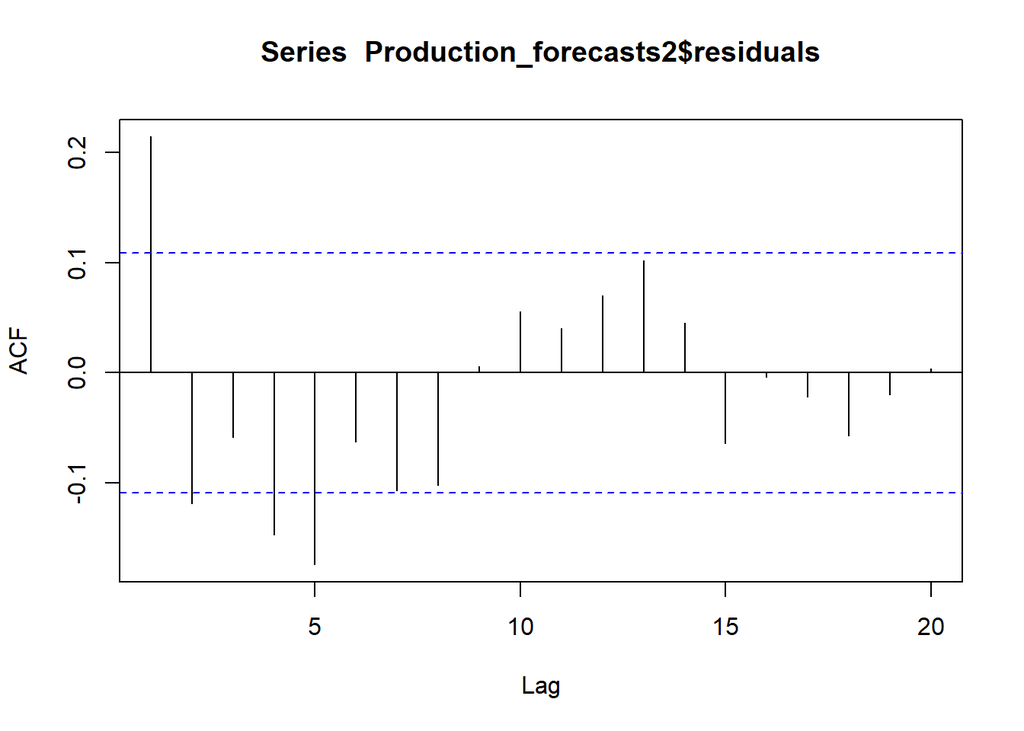

```r
# Check if the residuals have non-zero autocorrelation for the first 20 lags
Acf(Production_forecasts2$residuals, lag.max = 20)
```

The ACF plot of residuals shows some autocorrelations at lags 1,4 and 5. The ACF at lag 2 also touches the significance bound.

```r
# Test if the autocorrelations are significant using Ljung-Box test.
Box.test(Production_forecasts2$residuals, lag = 20, type="Ljung-Box")
```

```
##
##  Box-Ljung test
##
## data:  Production_forecasts2$residuals
## X-squared = 56.811, df = 20, p-value = 2.193e-05
```

The p-value of the Ljung-Box test is much lower than 0.05, providing enough evidence for the non-zero autocorrelation of the residuals. The assumption for zero autocorrelation between the error terms does not hold.

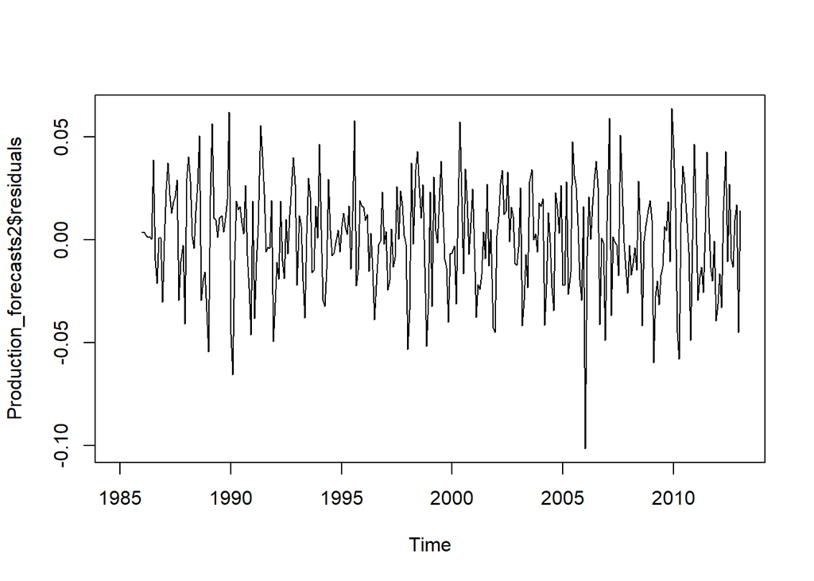

```r
# Do a time series plot of the residuals to check if the residuals have a constant variance
plot.ts(Production_forecasts2$residuals)
```

The plot shows that the residuals have a constant variance. The assumption for constant variance of the residual holds.

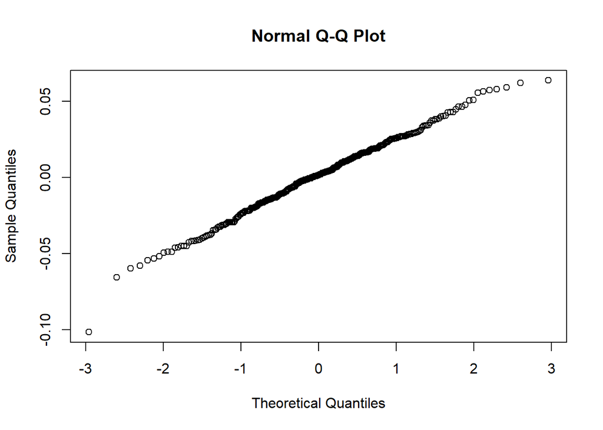

```r
# Check for normality of residuals
qqnorm(Production_forecasts2$residuals)
```

The qq-plot closely resembles a straight line, with little discrepancies on the tails. This implies that the residuals are normally distributed.

From the above ACF plot, Ljung-Box test and normality test for residuals, they show that the assumptions of normality and constant variance of the error terms are met, while that of zero autocorrelation isn’t met. Therefore, the Holt-Winters Exponential Smoothing model can still be improved upon.

# Evaluate the performance of Holt-Winters Exponential Smoothing model on test dataset

```r
## Calculate generalization error

# First convert the predictions to the original scale
obs <- round(2.718282^test, 4)
preds <- round(2.718282^Production_forecasts2$mean, 4)

# find test SSE and RMSE
test_SSE <- sum((obs - preds)^2)
test_SSE
```

```
## [1] 1174.783
```

```r
test_RMSE <- sqrt(test_SSE/60)
test_RMSE
```

```
## [1] 4.424897
```

Holt-Winters Exponential Smoothing model has a validation RMSE of 4.4249, implying that the predictions made by this model would be off by 4.4249 (plus or minus). Not that bad.

```r
# Build a SARIMA model using the auto.arima() function
sarima_model <- auto.arima(train, seasonal = TRUE)
# Have a model summary
summary(sarima_model)
```

```
## Series: train
## ARIMA(1,1,1)(1,1,2)[12]
##
## Coefficients:
##          ar1      ma1     sar1     sma1     sma2
##       0.5207  -0.9235  -0.4695  -0.2354  -0.4608
## s.e.  0.0589   0.0265   0.2304   0.2172   0.1649
##
## sigma^2 = 0.0005517:  log likelihood = 751.87
## AIC=-1491.74   AICc=-1491.48   BIC=-1469.06
##
## Training set error measures:
##                        ME       RMSE        MAE        MPE      MAPE      MASE
## Training set -0.001889036 0.02285151 0.01781252 -0.0425782 0.3981982 0.5553821
##                   ACF1
## Training set 0.0154996
```

The model is ARIMA(1,1,1)(1,1,2)[12]. Non-seasonal parameters are; p=1, d=1, q=1 (lag 1 differencing (*d*), an autoregressive term of first lag (*p*) and a moving average model of order 1 (*q*)). Seasonal parameters are P=1, D=1, Q=2, s=12. The training RMSE and MAE are relatively small indicating a good fit.

The Seasonal ARIMA fitted model is:

- Yt^=0.5207Yt−1−0.4695Yt−12−0.9235et−1−0.2354et−12−0.4608et−24+E, where E is some error.

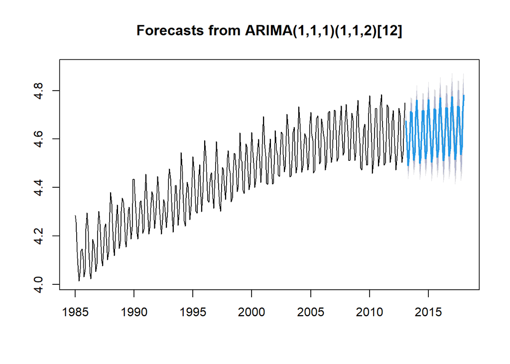

```r
# Forecast using SARIMA model (forecast for the next 60 months)
sarima_forecasts <- forecast(sarima_model, h = 60)

# Plot the full forecast
plot(sarima_forecasts)
```

The forecast follows the pattern of the series closely and steadily.

# Diagnostics for the Seasonal ARIMA model

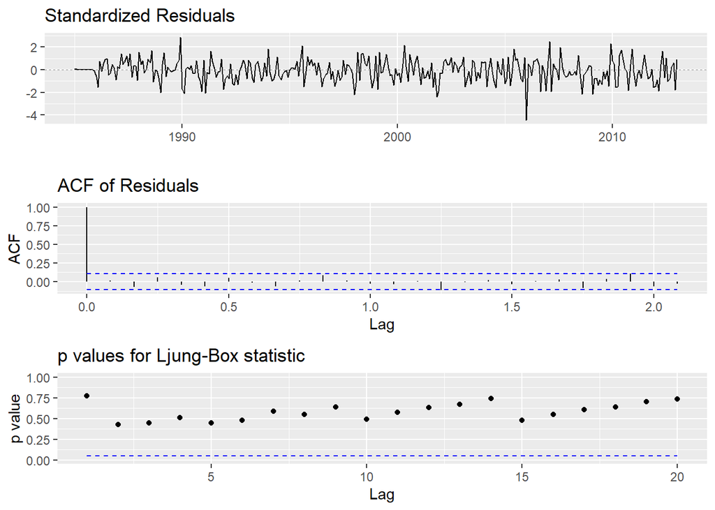

```r
# Check if there's significant autocorrelations between the residuals
ggtsdiag(sarima_model, gof.lag = 20)
```

- Some of the standardized residuals are greater than or less than 3, implying the presence of some outliers in the time series.
- The ACFs of the first 20 lags do not exceed the significance bounds, and the p-values from Ljung-Box test are also greater than 0.05, providing enough evidence of zero autocorrelations between the error terms.

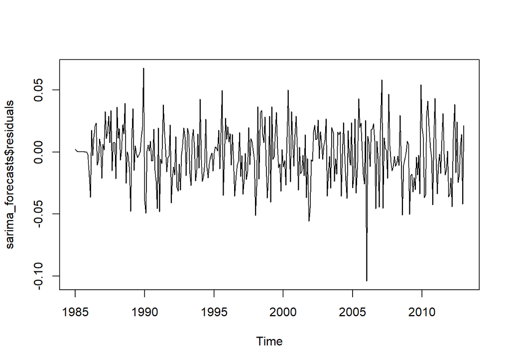

```r
# Do a time series plot of the residuals to check if the residuals have a constant variance
plot.ts(sarima_forecasts$residuals)
```

The plot shows that the residuals have a constant variance, with some little changes over time.

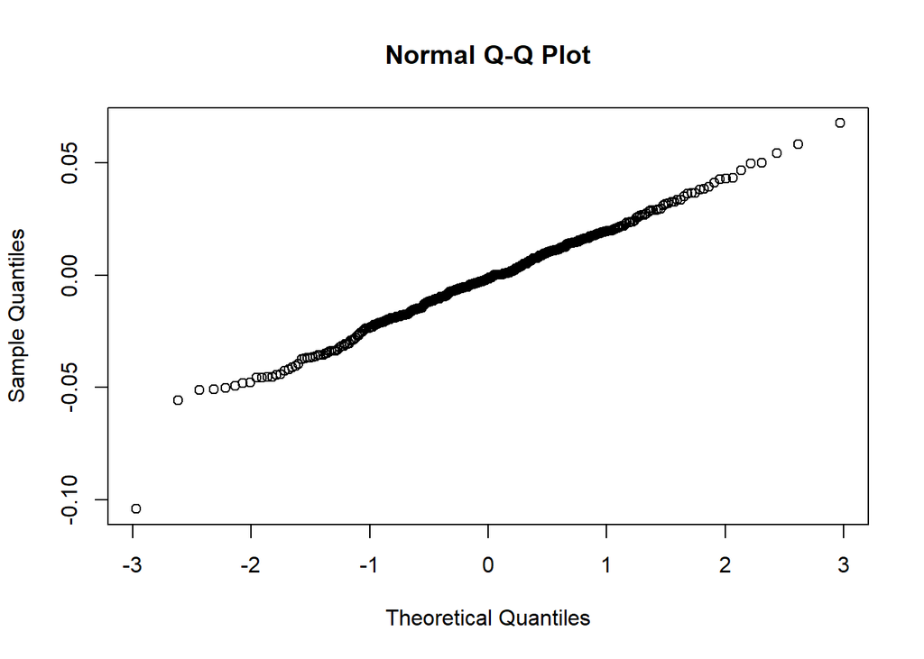

```r
# Check for normality of residuals
qqnorm(sarima_forecasts$residuals)
```

The qq-plot closely resembles a straight line, with little discrepancies on the lower tail.

All the assumptions for ARIMA model are therefore met.

# Evaluate performance of the SARIMA model on test data

```r
## Calculate generalization error

# First convert the predictions to the original scale
obs <- round(2.718282^test, 4)
sarima_preds <- round(2.718282^sarima_forecasts$mean, 4)

# find test SSE and RMSE
test_SSE2 <- sum((obs - sarima_preds)^2)
test_SSE2
```

```
## [1] 735.0271
```

```r
test_RMSE2 <- sqrt(test_SSE2/60)
test_RMSE2
```

```
## [1] 3.500064
```

SARIMA model has a validation RMSE of 3.5, performs better than Holt-Winters Exponential Smoothing model. Predictions made by the SARIMA model would be off by 3.5 (plus or minus).